# Deep Learning- 課程 05－Deep Learning- Single Shot MultiBox Detector -SSD -介紹 Images - 目標檢測 - Python Tutorial

''' 人工智慧- 進階課程 A.I Tutorials - Advanced Course - Deep Learning 教程 ''' 05 - 深度學習 教程 課程 05 - Deep Learning- - Single Shot MultiBox Detector Introduction - 程式範例 - Single Shot Detector(SSD) - GluonCV - 圖像- Image 目標檢測 - Multi Object Detection - 圖像- Image 目標檢測 ''' ''' >> 資料準備 >> 你我互動學習園地- 進階課程 Advanced Course >> https://interactiveuandmetutorialsac.weebly.com/ >> 你我互動學習園地 >> https://interactiveuandmetutorials.weebly.com/ >> Python 程式語言 設計 >> https://pythonprogrammingtutorials.weebly.com/ >> 目錄結構 : >> Deep Learning- 課程 05－Deep Learning- Single Shot MultiBox Detector -SSD -介紹 Images - 目標檢測.zip 檔案路徑/ ├── 課程 05－Deep Learning- Single Shot MultiBox Detector -SSD -介紹 - Images - 目標檢測 ipynb └── images/ ├── dog.jpg └── street_small.jpg ''' ''' >> SSD - 單次檢測器 - Single Shot Detector - SSD - 沒有 - 區域提議網絡 - Region Proposal Network - 僅一次通過功能 - Feature Maps - 直接預測 - 邊界框 - Boundary Boxes - 類 - Classes >> 為了提高準確性 - Improve Accuracy >> SSD 引入 >> 小型捲積濾波器 - Small Convolutional Filters - 用於預測 - 對像類別 - 默認邊界框 - 偏移量 Offset >> 默認框 - 單獨過濾器 - Separate FiltersDefault Boxes - 處理寬高比的差異 - Difference in Sspect Ratios >> 對象檢測 - 多尺度特徵圖 - Multi Scale Feature Maps >> 端到端 End-To-End - SSD 進行培訓 - 提高準確性 >> SSD - 更多預測 - 可以更好地覆蓋 - 位置 . 比例 , 寬高比 - Location, Scale and Aspect Ratios >> 上述改進 >> SSD可以 - 將輸入圖像分辨率 - 降低到 300 × 300 - 相對準確的性能 >> 通過刪除委託區域提案 - 並使用較低分辨率的圖像 >> 模型可以 - In Time - 運行 -- 並且 - 仍然優於 - Faster R-CNN '''

[figure not shown]

''' >> Single Shot MultiBox Detector - SSD 專為 Real-Time 目標檢測 - 設計 >> 區域卷積神經網絡 - R-CNN - Region-Convolutional Neural Network (R-CNN) >> 區域提議網絡 - Region Proposal Wetwork - 創建邊界框 - Boundary Boxes - 這些框對 對象 - 進行分類 - Classify Objects >> SSD - 認為是最先進的準確性 - Accuracy - 每秒 7 幀 -7 Frames Per Second - SSD - 拿掉 - 區域提議網絡 - Region Proposal Network - 需求 - 加快 - 該檢測過程 - 恢復 - 準確性下降 - 使用 -較低分辨率的圖像 - Lower Resolution Images - 配 Faster R-CNN 的 準確度 - Accuracy - SSD - 進行一些改進 - 包括 - 多尺度功能 - Multi Scale Features - Default Boxes >> 準確度 - 平均準確度 - mAP - Mean Average Precision mAP - 預測 - 準確度 - Precision Of The Predictions '''

[figure not shown]

''' >> SSD: Single Shot MultiBox Detector - 提取特徵圖 - Extract feature maps - 卷積過濾器 - 檢測對象 - Convolution Filters - Detect Objects >> SingleMultiBox檢測器 - Architechture 結構 - 輸入 - 300 x 300 x 3 '''

[figure not shown]

''' >> SSD - 結構 - 建立在 - VGG-16 上 - 丟棄了 - 完全連接的層 FC Layer - VGG-16 用作- 基礎網絡的原因 - 由於在高質量圖像 - 分類任務中 - 強大性能 - 傳輸學習 -助於 改善結果的問題中 - 廣泛應用 - 代替原始的 VGG 全連接層 - Fully Connected Layers - 添加了一組輔助卷積層- 從 conv 6 開始 - 能夠以多個比例 - Extract Features - 提取特徵 - Extract Features - 逐漸減小每個後續層 - 輸入大小 '''

[figure not shown]

''' >> SSD - VGG16 提取特徵圖 - Extract Feature Maps '''

[figure not shown]

''' >> VGG16 網絡 - 結構 '''

[figure not shown]

''' >> Detects Objects - Conv4_3 Layer - 檢測對象 - 8 × 8 - 38 × 38 - 每個單元格 Each Cell - 位置 - Location - 對象預測 - Object Predictions - 4 個 Units '''

[figure not shown]

''' >> 每個預測 - 由 - 一個邊界框 - 每個類的 21個 - 得分 Scores - 組成 - 沒有對象的 - 額外一個類 - 選擇最高得分 - 作為 - 有 - 對象的類 - SSD - 保留 - Classs " 0 " - 表示 - 沒有對象 - SSD reserves a class " 0 " - " indicate it has no objects - >> 每個預測 - 包括一個邊界框 21個類 - 21個得分 - 一個類 - 沒有對象 >> 多框 - Multi-Box - 進行包含 - 邊界框 - Boundary Boxes - 置信度分數 - Confidence Scores - 多個預測 - Multiple Predictions '''

[figure not shown]

''' >> 目標檢測 Object Detection >> 捲積預測 - Convolutional Predictors >> SSD - 不使用 -區域提議網絡 - Not Use Region Proposal Network - 簡單的方法 -Very Simple Method - Small Convolution Filters - Computing - Location - Class Scores >> 提取特徵圖後 - Extracting the Feature Maps - 每個單元 Each Cell - 3×3卷積濾波器 - Convolution Filters - 進行預測 - Predictions - Each Filter Outputs - 25 channels - 每個類別 Each Class - 21 Scores - 一個邊界框 Boundary Box - One '''''' >> 3x3 卷積濾波器 - Convolution Filter - 位置 - Location - 類別 - Class - 進行預測 >> Conv4_3 - - 四個 - 3×3 濾波器 - 512個 - 輸入通道映射 - 25個 - 輸出通道 '''

[figure not shown]

''' >> 目標檢測 -Objects Detection - 多尺度特徵圖 - Multi-scale feature maps - 多尺度特徵圖 - 獨立檢測對象 >> 隨著 - CNN - 逐漸減小 - 空間尺寸 - 特徵圖 - 分辨率 - 也會降低 >> SSD使用 - 較低分辨率的圖層 - 來檢測較大規模的對象 - 例如 - 4×4 特徵圖 - 用於 較大比例的對象 >> 較低分辨率的特徵圖（右） - 可檢測較大比例的對象 '''

[figure not shown]

''' >> SSD - VGG16 之後 >> 增加了 - 6個 - 輔助卷積層 >> 其中五個 - 將 添加 - 用於對象檢測 >> 在其中的三個層中 - 做出 6個預測 - - 而不是 4個 >> SSD - 使用 - 6個層 - 做出了 - 8732個 -預測 '''

[figure not shown]

''' >> 多尺度特徵圖 - Multi Scale Feature Map - 提高了準確性 - Accuracy - 用於對象檢測 - 不同數量的 - 特徵圖圖層的準確性 - Accuracy - Different Number of Feature Map Layers '''

[figure not shown]

''' >> 默認邊界框 - Default Boundary Box - Faster R-CNN中 - 錨點 Anchors '''''' >> 如何預測邊界框 - 深度學習一樣 - 隨機預測 - 開始 - 梯度下降 - 優化模型 >> 初始訓練期間 - 模型可能會 - 相互競爭 - 確定要 - 針對哪些預測優化的形狀（行人或汽車） - 早期訓練 - 可能非常不穩定 >> 下面的邊界框預測 - 適用於一種類別 - 但不適 - 用於 - 其他類別 >> 如果預測不多樣化 - 模型將無法執行 '''

[figure not shown]

''' >> 如果 - 預測涵蓋了 - 更多形狀 - 例如 -更多形狀 - 模型可以檢測到更多的對像類型 - 訓練 - 變得更加 - 輕鬆 和 穩定 >> 更多形狀 - 模型 - 涵蓋了更多的 - 對像類型 - Object Types '''

[figure not shown]

''' >> 現實中 - Real-Life >> 邊界框 - Boundary Boxes - 沒有任意形狀和大小 >> 汽車的形狀 - 相似 >> 汽車/行人的 - 長寬比 約為 - 0.41 - Aspect Ratio of 0.41 - 自動駕駛中 - KITTI 數據集中 - 邊界框 Boundary Boxes的 寬度和 高度分佈 - 高度聚集 - Clustered '''

[figure not shown]

''' >> 邊界框劃分為 - 群集 - 每個群集由 - 默認邊界框（群集的質心）表示 - k-means Cluster - 進行 - 隨機猜測外 - 猜測 - 這些默認框 >> SSD 可以將默認框 - 保持為最小值 - 4 或 6 - 每個默認框 - 具有一個預測 - 邊界框預測 -相對於每個單元格的 默認邊界框（∆cx，∆cy，w，h） - 而不是對框位置使用全局坐標 - Global Coordination - 相對於 - 每個單元格的默認框 Default Box - 偏移量 - Offsets '''

[figure not shown]

''' >> 每個特徵圖- 圖層 Each Feature Map Layers >> 共享 相應單元為中心的 - 同一組默認框 >> Shares the same set of default boxes centered at the corresponding cell >> 不同的圖層 - 使用不同的默認框集來自定義不同分辨率的對象檢測 - Different layers use different sets of default boxes - customize object detections at different resolutions >> 4個綠色框 - 4個 - 默認邊界框 >> 4 Green Boxes - 4 Default Boundary Boxes '''

[figure not shown]

''' >> 選擇默認邊界框 -手動選擇 '''

[figure not shown]

''' >> SSD - 為每個特徵圖- 圖層定義了一個比例值 - 左側開始 - Conv4_3 - 最小比例0.2（有時為0.1）- 檢測對象 - 然後 - 0.9的比例 - 線性增加 到最右邊的圖層 - 結合比例值和目標縱橫比 - 計算默認框的寬度和高度 - 做出 - 6個預測 - 圖層 - SSD - 5個目標 - 縱橫比 - 1 , 2 , 3 ,1/2 ,1/3 - 默認框的 寬度和 高度計算 '''

[figure not shown]

''' >> 長寬比 = 1 >> YOLO - 訓練數據集 - 使用 k-means 聚類 - 確定 默認邊界框 - Default Boundary Boxes '''

''' >> 匹配 - Matching >> SSD 預測分類 - Predictions are Classified - 正匹配 Positive matches - 不匹配 Negative matches >> 相應的 默認邊界框（而非預測邊界框） - IoU 大於 > 0.5 - 基於地面實況 - 匹配為正 - 否則為負 >> IoU - 聯合的交集 - 兩個區域 - 相交區域 與 合併區域 - 之間的比率 '''

[figure not shown]

''' >> 真實對象（藍色）和 3個默認邊界框（綠色) - Ground truth object (Blue) - 3 Default Boundary Boxes (Green) '''''' >> 簡化 - 為 3個 默認框 - 只有默認框 1和 2 - 不是3 - IoU 大於 > 0.5 - 方框 1 和 2 - 是 - 正匹配 - Positive matches >> 一旦確定了 - 正面匹配 -使用相應的預測邊界框 - 計算成本 - Calculate Cost >> 匹配策略 - 每個預測 - 預測更接近相應默認框的形狀 - 因此 - 預測在訓練中 - 更加多樣化和穩定 >> This matching strategy encourages each prediction to predict shapes closer to the corresponding default box. Therefore our predictions are more diverse and more stable in the training. >> Default box(2) - IoU大於0.5 >> Default box 2 units - Ground Truth - IoU '''

[figure not shown]

''' >> 多比例 特徵圖 要素 - Multi-Scale Feature Maps - 默認邊界框 - Default Boundary Boxes >> SSD 結合 - 多尺度特徵圖 和 默認邊界框 - 檢測不同尺度的對象的 >> 下面 - 狗 與 4×4要素 特徵圖 中 - 的一個默認框（紅色）匹配 - 但與高分辨率 8 × 8要素圖中 - 的任何默認框都不匹配 - 由2個默認框中 - 8×84×4要素 特徵圖（藍色） - 檢測 到較小的貓 '''

[figure not shown]

''' >> 高分辨率特徵圖 - 負責檢測小物體 - 對象檢測 - 第一層 conv4_3的 空間尺寸 - 38×38 - 與輸入圖像相比 - 有很大的減小 >> 其他 - 檢測方法相比 - SSD 通常對小物體的性能較差 - 如果有問題 - 可以使用 - 更高分辨率的圖像 - Images with Higher Resolution - 來解 '''

[figure not shown]

''' >> 資料擴充 - Data augmentation - 數據擴充對於提高準確性 - 很重要 - 翻轉 Flipping - 裁切 Cropping - 顏色失真 Color Distortion - 增強數據 >> 每個訓練圖像 - 隨機採樣 - Sampling Original - 原版 - Sampling Original - IoU of 0.1, 0.3, 0.5, 0.7 or 0.9 - Sample a Patch - 隨機採樣 - Randomly sample a patch >> Patch 採樣 - sampled patch - 長寬比 - 1/2 - 2 之間 >> 將其調整為固定大小 - Fix Size - 訓練數據 - 翻轉一半 - Flip One- Falf etc .. '''

[figure not shown]

''' >> 數據擴充後的 - 性能改進 >> Data Augmentation - Performance Improvement '''

[figure not shown]

''' >> 預測/推斷時間 - Inference time >> SSD -預測 - 8732 - 更好地 - 覆蓋 - 位置 - 比例 - 縱橫比 - 許多預測都沒有對象 - 因此 - 類別置信度得分 - 低於0.01 的預測 - 消除 - Eliminated >> SSD - 做出更多預測 - 使用較低分辨率的圖像 - 達到類似的 精度 - Accuracy '''

[figure not shown]

''' >> SSD - 非最大抑制 - Non-Maximum Suppression - nms - 非最大抑制 - 刪除 - 同一對象的 - 重複預測 - 通過 - 置信度得分 -對預測 - 進行排序 - 最高置信度預測開始 - 根據同一類別的當前預測 - 評估是否先前預測的邊界框的 - IoU 高於 > 0.45 - 如果找到 - 則當前預測將被忽略 - 最多 - 保留每個圖像的 - 前200個 - 預測 '''

[figure not shown]

''' >> SSD - Single Shot Detector - 速度性能 每秒幀- Speed Performance - Frame Per Second speed performance 每秒幀速度性能 '''

[figure not shown]

# 程式範例

''' >> 查看原始照片 - Review Orginal Phote '''

```python
import cv2
cv2.__version__
```

```
'4.1.0'
```

```python
import cv2
import numpy as np
import matplotlib.pyplot as plt
%matplotlib inline
```

```
(576, 768, 3)
```

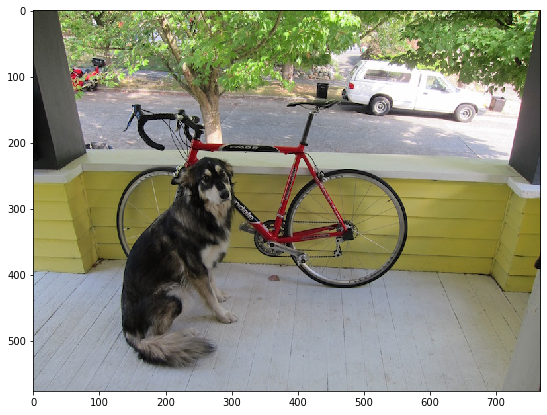

```python
img = cv2.imread('images/dog.jpg')
img = cv2.cvtColor(img, cv2.COLOR_BGR2RGB)
plt.figure(figsize = (20, 20))
plt.subplot(1, 2, 1); plt.imshow(img)
img.shape
```

```
(512, 512, 3)
```

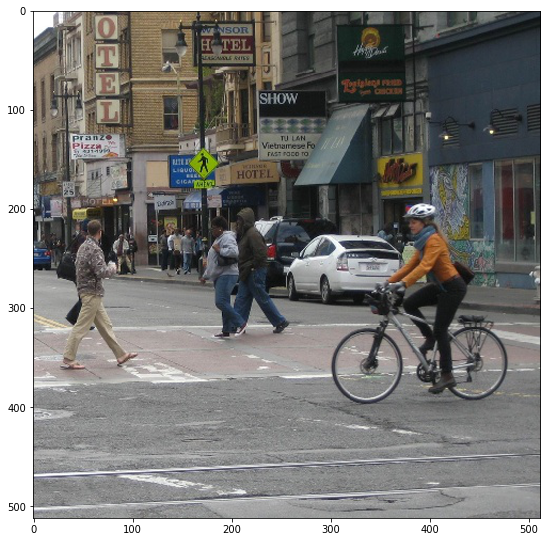

```python
img = cv2.imread('images/street_small.jpg')
img = cv2.cvtColor(img, cv2.COLOR_BGR2RGB)
plt.figure(figsize = (20, 20))
plt.subplot(1, 2, 1); plt.imshow(img1)
img1.shape
```

```python
!python -V
```

```
Python 3.7.3
```

# pip Installation mxnet and gluoncv - model_zoo # Model Zoo - Classification on Object Detection pip install --upgrade mxnet gluoncv

```python
!pip install --upgrade mxnet gluoncv
```

## 載入相關函式庫 - Load related library

```python
from gluoncv import model_zoo, data, utils
from matplotlib import pyplot as plt
```

''' >> 預訓練模型 - net = model_zoo.get_model('ssd_512_resnet50_v1_voc', pretrained=True) >> 加載預訓練的模型 - Load ssd_512_resnet50_v1_voc >> 獲得一個以ResNet-50 V1 - 為基本模型 - Pascal VOC 數據集上 - 512x512圖 像進行訓練的 SSD模型。 - 通過指定 - pretrained = True - 它自動從模型 model_zoo 中 -下載模型

## 加載預訓練的模型 - Load ssd_512_resnet50_v1_voc

```python
net = model_zoo.get_model('ssd_512_resnet50_v1_voc', pretrained=True)
```

## 預處理圖像 Pre-process an image

''' >> 下載圖像，並使用預設的數據轉換進行預處理 - 指定將圖像的短邊尺寸調整為 512 像素 - 可以 輸入任意大小的圖像 - YOLO的限制條件 - 輸入的 高度 和 寬度 可以除以32 >> gluoncv.data.transforms.presets.yolo.load_test - 形狀為（batch_size，RGB_channels，height，width）的 NDArray - 可以直接將其 輸入模型 >> 僅加載單個圖像，因此x的第一維為 1 - Shape of pre-processed image: (1, 3, 512, 683) '''

```python
im_fname = utils.download('https://raw.githubusercontent.com/zhreshold/' +
                          'mxnet-ssd/master/data/demo/dog.jpg',
                          path='dog.jpg')
x, img = data.transforms.presets.yolo.load_test(im_fname, short=512)
print('Shape of pre-processed image:', x.shape)
```

```
Shape of pre-processed image: (1, 3, 512, 683)
```

```python
im_fname1 = utils.download('https://github.com/dmlc/web-data/blob/master/' +
                          'gluoncv/detection/street_small.jpg?raw=true',
                          path='street_small.jpg')
x, img1 = data.transforms.presets.ssd.load_test(im_fname1, short=512)
print('Shape of pre-processed image:', x.shape)
```

```
Shape of pre-processed image: (1, 3, 512, 512)
```

## 檢/ 偵測 和 顯示 - Detection and Display

''' >> 返回所有檢測到的 - 邊界框 - Bounding Boxes - 相應的預測類ID - Predicted Class IDs - 置信度分數 - Confidence Scores >> 形狀分別是 - batch_size，num_bboxes，1 - batch_size，num_bboxes，1 - batch_size，num_bboxes，4 >> 使用：py：func：gluoncv.utils.viz.plot_bbox 可視化結果 >> 第一個圖像的結果切成薄片，並將其輸入 - plot_bbox 中 '''

[figure not shown]

```python
class_IDs, scores, bounding_boxs = net(x)

ax = utils.viz.plot_bbox(img, bounding_boxs[0], scores[0],
                         class_IDs[0], class_names=net.classes) # scores[0],
plt.show()
```

[figure not shown]

```python
class_IDs, scores, bounding_boxs = net(x)

ax = utils.viz.plot_bbox(img1, bounding_boxs[0], scores[0],
                         class_IDs[0], class_names=net.classes) # scores[0],
plt.show()
```

''' >> 參考: - [YOLO官網] >> https://pjreddie.com/darknet/yolo/ - [llSourcell/YOLO_Object_Detection] >> https://github.com/llSourcell/YOLO_Object_Detection - [allanzelener/YAD2K] >> https://github.com/allanzelener/YAD2K '''